# 2.7 — Hypothesis Testing for Regression — R Practice

Author

Answer Key

Published

October 12, 2022

# Required Packages & Data

Load all the required packages we will use (**note I have installed them already into the cloud project**) by running (clicking the green play button) the chunk below:

```r
library(tidyverse) # your friend and mine
library(broom) # for tidy regression
library(modelsummary) # for nice regression tables
library(infer) # for simulating inference
```

**What is the effect of a diamond’s carat size on its price?**

We will use the `diamonds` example dataset that comes bundled with `ggplot`, automatically loaded with `tidyverse`. To make it an explicit tibble in our workspace, run the code below.

```r
diamonds <- diamonds
```

Note I am calling the tibble `diamonds`, feel free to name it whatever you like, but I will assume in my code chunks below that you are calling it `diamonds` - change as appropriate.

## Question 1

Just to see what we’re looking at, make a scatterplot using `ggplot()`, with `x` as `carat` and `y` as `price`, and add a regression line.

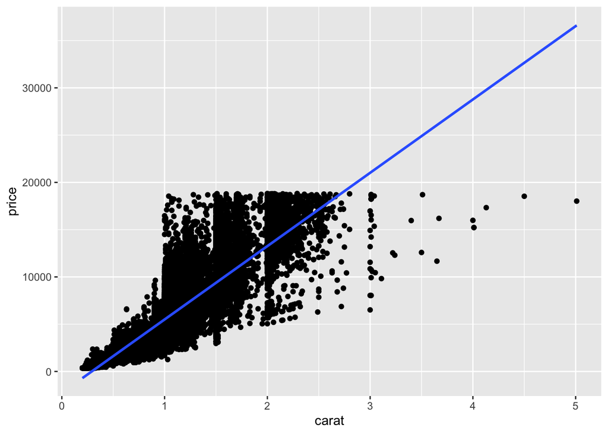

```r
# type your code below in this chunk
ggplot(data = diamonds)+
  aes(x = carat,
      y = price)+
  geom_point()+
  geom_smooth(method = "lm")
```

# Regression

## Question 2

Suppose we want to estimate the following relationship:

$$\text{Price}_i = \beta_0+\beta_1 \, \text{carat}_i+u_i$$

Run a regression of `price` on `carat` using `lm()` and get a `summary()` of it. Be sure to save your regression model as an object, we’ll need it later.

```r
# type your code below in this chunk
reg <- lm(price ~ carat, data = diamonds)

summary(reg)
```

```
Call:
lm(formula = price ~ carat, data = diamonds)

Residuals:
     Min       1Q   Median       3Q      Max
-18585.3   -804.8    -18.9    537.4  12731.7

Coefficients:
            Estimate Std. Error t value Pr(>|t|)
(Intercept) -2256.36      13.06  -172.8   <2e-16 ***
carat        7756.43      14.07   551.4   <2e-16 ***
---
Signif. codes:  0 '***' 0.001 '**' 0.01 '*' 0.05 '.' 0.1 ' ' 1

Residual standard error: 1549 on 53938 degrees of freedom
Multiple R-squared:  0.8493,    Adjusted R-squared:  0.8493
F-statistic: 3.041e+05 on 1 and 53938 DF,  p-value: < 2.2e-16
```

## Question 3

### Part A

Write out the estimated regression equation.

$$\widehat{price}_i=−2256.36+7756.43 \, \text{carat}_i$$

### Part B

Make a regression table of the output (using the `modelsummary` package).

```r
# type your code below in this chunk
modelsummary(models = list("Price" = reg),
             fmt = 2, # round to 2 decimals
             output = "html",
             coef_rename = c("(Intercept)" = "Constant",
                             "carat" = "Carat"),
             gof_map = list(
               list("raw" = "nobs", "clean" = "n", "fmt" = 0),
               list("raw" = "r.squared", "clean" = "R<sup>2</sup>", "fmt" = 2),
               #list("raw" = "adj.r.squared", "clean" = "Adj. R<sup>2</sup>", "fmt" = 2),
               list("raw" = "rmse", "clean" = "SER", "fmt" = 2)
             ),
             escape = FALSE,
             stars = c('*' = .1, '**' = .05, '***' = 0.01)
)
```

|  | Price |
| --- | --- |
| Constant | −2256.36*** |
|  | (13.06) |
| Carat | 7756.43*** |
|  | (14.07) |
| n | 53940 |
| R<sup>2</sup> | 0.85 |
| SER | 1548.53 |

* p < 0.1, ** p < 0.05, *** p < 0.01

### Part C

What is the estimated $\hat{\beta}_1$ for this model? What does it mean in terms of the context of our question?

$\hat{\beta}_1$, the estimated slope, is 7756.43. For every 1 carat, we expect the price of the diamond to increase by $7,756.43.

```r
# type your code below in this chunk
```

### Part D

Use the `broom` package’s `tidy()` command on your regression object, and calculate confidence intervals for your estimates by setting `conf.int = T` inside `tidy()`.

What is the 95% confidence interval for $\hat{\beta}_1$, and what does it mean?

```r
# type your code below in this chunk
reg_tidy <- reg %>%
  tidy(conf.int = T)

reg_tidy
```

| term | estimate | std.error | statistic | p.value | conf.low | conf.high |
| --- | --- | --- | --- | --- | --- | --- |
| (Intercept) | -2256.361 | 13.05535 | -172.8304 | 0 | -2281.949 | -2230.772 |
| carat | 7756.426 | 14.06658 | 551.4081 | 0 | 7728.855 | 7783.996 |

**We are 95% confident that in similarly constructed samples, the true effect of carat on price** (β1) **is between $7,728.86 and $7,784.00.**

Save these endpoints as an object by running the following code (and changing it for your object names as needed):

```r
# save confidence interval
ci_endpoints <- reg_tidy %>% # use whatever your tidy regression object is named
  filter(term == "carat") %>%
  select(conf.low, conf.high)

# look at it
ci_endpoints
```

| conf.low | conf.high |
| --- | --- |
| 7728.855 | 7783.996 |

### Part E

Save your estimated $\hat{\beta}_1$ as an object similarly by running and changing the code below if needed. We’ll need it later.

```r
# save our slope
our_slope <- reg_tidy %>% # use whatever your tidy regression object is named
  filter(term == "carat") %>%
  pull(estimate)

# look at it
our_slope
```

```
[1] 7756.426
```

## Question 4

### Part A

Let’s generate a confidence interval for $\hat{\beta}_1$ by simulating the sampling distribution of $\hat{\beta}_1$. Run the following code, which will `specify()` the model relationship and `generate()` 1,000 repetitions using the `bootstrap` method of resampling data points randomly from our sample, with replacement.

```r
# save our simulations as an object (I called it "boot")
boot <- diamonds %>% # or whatever you named your dataframe!
  specify(price ~ carat) %>% # our regression model
  generate(reps = 1000, # run 1000 simulations
           type = "bootstrap") %>% # using bootstrap method
  calculate(stat = "slope") # estimate slope in each simulation

# look at it
boot
```

| replicate | stat |
| --- | --- |
| 1 | 7751.791 |
| 2 | 7762.947 |
| 3 | 7772.735 |
| 4 | 7761.695 |
| 5 | 7766.859 |
| 6 | 7743.538 |
| 7 | 7758.314 |
| 8 | 7771.372 |
| 9 | 7755.629 |
| 10 | 7747.328 |

[output cut: 990 more lines]

Note this will take a few minutes, its doing a lot of calculations! What does it show you when you look at it?

**This produces 1,000 bootstrapped samples, and calculates the estimated regression slope** $\hat{\beta}_1$ **for each sample.**

### Part B

Continue by piping your object from Part A into `get_confidence_interval()`. Set `level = 0.95, type = "se"` and `point_estimate` equal to our estimated $\hat{\beta}_1$ (saved) from above as `our_slope`.

```r
boot %>%
  get_confidence_interval(level = 0.95,
                          type = "se",
                          point_estimate = our_slope)
```

| lower_ci | upper_ci |
| --- | --- |
| 7707.758 | 7805.093 |

### Part C

Now instead of `get_confidence_interval()`, pipe your object from Part A into `visualize()` to see the sampling distribution of $\hat{\beta}_1$ we simulated. We can add `+ shade_ci(endpoints = ...)` setting the argument equal to whatever our object containing the confidence interval from Question 2 Part D (I have it named here as `ci_endpoints`).

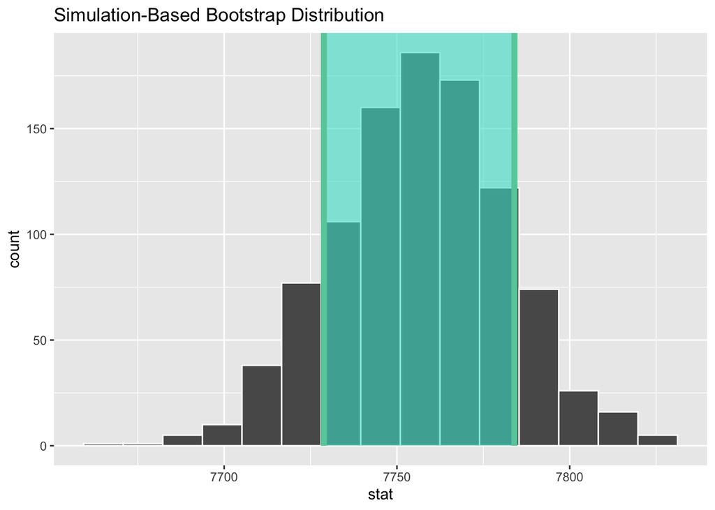

```r
boot %>%
  visualize()+
  shade_ci(endpoints = ci_endpoints)
```

Compare your *simulated* confidence interval with the *theoretically-constructed* confidence interval from the output of `tidy()` from Question 3.

```r
# type your code below in this chunk
```

# Hypothesis Testing

## Question 5

Now let’s test the following hypothesis:

$$\begin{align*}
H_0: & \, \beta_1 = 0 \\
H_a: & \, \beta_1 \neq 0 \\ \end{align*}$$

### Part A

Is this a one-sided or a two-sided test?

**This is a two-sided test, because we are considering the possibility that** $\beta_1$ **may be above or below the null hypothesis value of 0.**

### Part B

Look back at the regression `summary()` output from question 2, and the output of `tidy()` from question 3. What does it tell you about this hypothesis test?

**Reading the second row of estimates from the `lm summary` or `tidy` output of question 2, we saw that the `estimate` on `carat`** $\hat{\beta}_1$ **was 7756.43, with a standard error of 14.07. This yields a test statistic value of 551.4, and a p-value of basically 0.**

### Part C

Let’s now do run this hypothesis test with `infer`, which will simulate the sampling distribution under the null hypothesis that $\beta_1=$. Run the following code, which will `specify()` the model relationship and `hypothesize()` the null hypothesis that there is no relationship between X and Y (i.e. $\beta_1=0$), and `generate()` 1,000 repetitions using the `permute` method, which will center the distribution at 0, and then `calculate(stat = "slope")`.

```r
# save our simulations as an object (I called it "test_sims")
test_sims <- diamonds %>% # or whatever you named your dataframe!
  specify(price ~ carat) %>% # our regression model
  hypothesize(null = "independence") %>% # H_0 is that slope is 0
  generate(reps = 1000, # run 1000 simulations
           type = "permute") %>% # using permute method, centering distr at 0
  calculate(stat = "slope") # estimate slope in each simulation

# look at it
test_sims
```

| replicate | stat |
| --- | --- |
| 1 | -1.380014e+01 |
| 2 | -2.888326e+00 |
| 3 | 3.677241e+01 |
| 4 | 7.849708e+01 |
| 5 | -1.066372e+01 |
| 6 | 6.571537e+01 |
| 7 | -2.122628e+01 |
| 8 | 6.104581e+01 |
| 9 | 4.216842e+01 |
| 10 | 9.090380e+00 |

[output cut: 990 more lines]

Note this may also take a few minutes. What does it show you?

**This produces 1,000 permuted samples, under the assumption that the true slope is 0 (the null hypothesis), and calculates the estimated regression slope** $\hat{\beta}_1$ **for each sample.**

### Part D

Pipe your object from the previous part into the following code, which will `get_p_value()`. Inside this function, we are setting `obs_stat` equal to our β1^ we found (from Question 2 part E), and set `direction = "both"` to run a *two*-sided test, since our alternative hypothesis is two-sided, $H_a: \beta_1 \neq 0$

```r
test_sims %>%
  get_p_value(obs_stat = our_slope,
              direction = "both")
```

```
Warning: Please be cautious in reporting a p-value of 0. This result is an
approximation based on the number of `reps` chosen in the `generate()` step. See
`?get_p_value()` for more information.
```

| p_value |
| --- |
| 0 |

Note the warning message that comes up!

### Part E

Instead of `get_p_value()`, pipe your simulations into the following code, which will `visualize()` the null distribution, and (in the second command), place our finding on it and `shade_p_value()`.

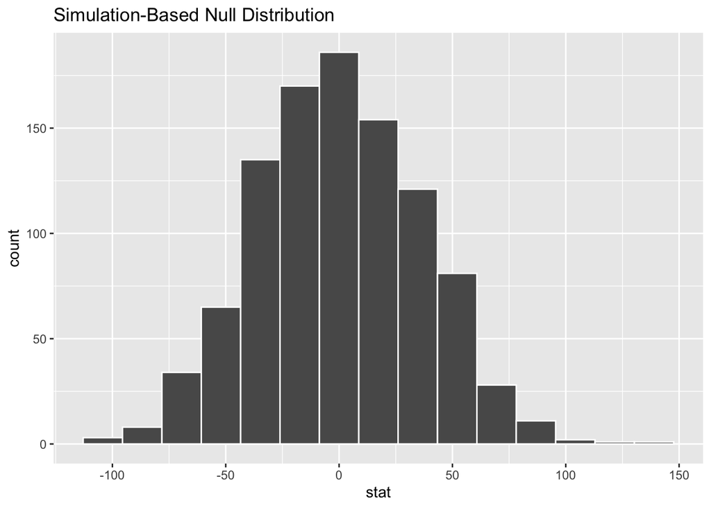

```r
test_sims %>%
  visualize()
```

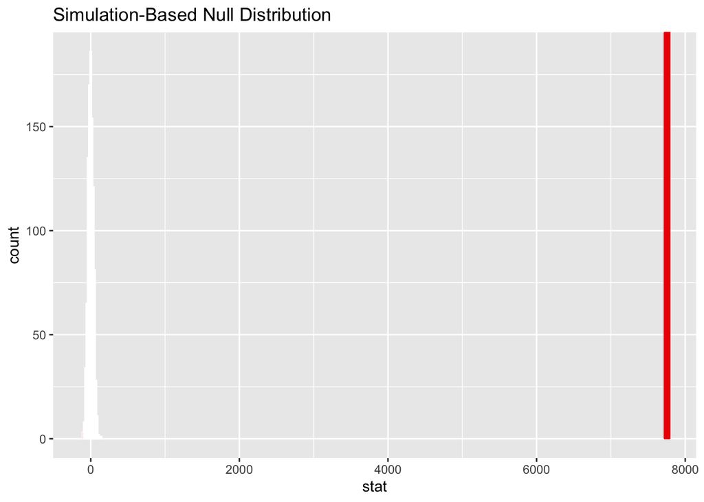

```r
test_sims %>%
  visualize()+
  shade_p_value(obs_stat = our_slope,
                direction = "both") # for two-sided test
```

### Part F

Compare your *simulated* p-value with the *theoretically-constructed* p-value from the output of `summary`, and/or of `tidy()` from Question 2 and 3.

Both `summary` and `tidy()` also report the t-statistic (`t value` or `statistic`) on this test for `carat` (by default, that $H_0: \beta_1 = 0$).

What is the estimated test statistic for this model, and what does this number mean? Try to calculate it yourself with the formula:

$$\text{Test statistic} = \frac{\text{estimate — null hypothesis}}{\text{standard error of the estimate}}$$

$$\begin{align*}
t &= \frac{7756.43-0}{14.07} \\
& \approx 551.3
\end{align*}$$

**If the null hypothesis were true** $\beta_1=0$**, the probability that we get a test-statistic at least as extreme as 551.3 (essentially, 551 standard deviations away!!) is virtually 0. You can see this when we visualize using `infer`, above.**

The p-value is the probability of a t-statistic at least as large as ours if the null hypothesis were true. `R` constructs a t-distribution with `n-k-1` degrees of freedom (`n` is number of observations, `k` is number of X-variables) and calculates the probability in the tails of the distribution beyond this t value. You can calculate it yourself (for a two-sided test) with:

```r
2 * pt(551.3, # our t-statistic
       df = 53938, # n - 2
       lower.tail = F) # we'll use the right tail
```

```
[1] 0
```